Eerste beweging · Verschil onder de loep

# Hoofdstuk 2 — De vorm van de hoop

Mediaan, kwartielen, boxplot en scheefheid

> **Bronnen (Bib, transcript):** `uitleg-kwartielen-mediaan-van-de-helft` (“ik tel gewoon met mijn vingers”), `berekening-five-number-summary-mediaan-positie-n-plus-1-door-2` (twee vragen: wáár zit hij, wát is hij), `berekening-iqr-uitbijters-anderhalf-keer`, `uitleg-boxplot-box-breedtes-homogeen-heterogeen`, `verhaal-frame-willem-alexander-mediaan-robuust`. Getallen kloppen: glans gesorteerd → mediaan 50 (= gemiddelde), Q1 = 30, Q3 = 70, IQR = 40, geen uitbijters; modus 30. Vier dieren × twaalf diamantjes = drie per kwart.

## 1. De verdeling

GROF — verdeel-scène; stem-pas volgt. Motief van de dieren is verdelen (schat!), niet lesgeven. De pointe — sorteren, het midden, de kwarten — is bijvangst. En het slot verklaart waarom de diamantjes in H4 nog bij elkaar liggen.

“We moeten ze natuurlijk wel verdelen,” zei de kraai op een middag, alsof het haar net pas inviel. Ze zei het te snel voor iemand die het net pas was ingevallen.

“Verdelen,” herhaalde de bever. Hij dacht na. “Twaalf diamantjes, vier dieren. Drie voor ieder.”

“Drie voor ieder,” zei de kraai, “maar niet zomaar drie. Ik wil de felle.”

“Dat is geen verdelen,” zei de meeuw. “Dat is uitkiezen.”

Ze besloten het eerlijk te doen. De bever legde de diamantjes op een rij, van dof naar fel — dat duurde even, want twee diamantjes waren het oneens over wie doffer was, en de bever moest ze allebei drie keer optillen.

Toen lag daar de rij. Van de dofste tot de felste, en alles ertussenin.

“Kijk,” zei de bever, niet zonder trots. “Nu zie je pas hoe ze verdeeld zijn. Hier zit het midden. En als ieder een kwart van de rij neemt —” hij wees met zijn staart de plekken aan waar je de rij in vieren hakt, “— dan heeft niemand iets te klagen. Behalve wie het doffe kwart krijgt.”

“Ik,” zei de kraai, “in elk geval niet.”

De olifant had nog niets gezegd. Hij keek naar de rij, heel lang, zoals alleen olifanten kijken.

“Als je ze verdeelt,” zei hij toen, “is de rij weg.”

Niemand zei iets terug. De rij lag daar, van dof naar fel, en was ineens zelf iets geworden — iets wat geen van de vier dieren in zijn eentje kon hebben.

Ze lieten de diamantjes liggen. Bij elkaar.

Docent-aansluiting: De bever heeft — zonder het te willen — het woord van dit hoofdstuk uitgelegd. Een **verdeling** is precies dat: hoe de boel verdeeld ligt als je hem op een rij legt. Waar het opeenhoopt, waar het dun wordt, waar het midden zit, waar de uiteinden liggen. En de olifant heeft er meteen de waarschuwing bij geleverd: de rij zelf is informatie. Wie alleen het gemiddelde bewaart, gooit de rij weg.

## 2. De rij — sorteren, het midden, de kwarten

### Eerst sorteren

Leg de glans-scores van onze twaalf op een rij, van laag naar hoog:

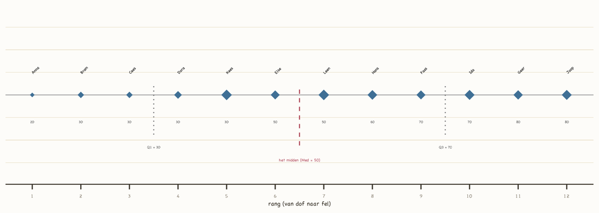

Figuur v1 (ggplot); hand-stijl-pas later. Merk op wat de rij gratis weggeeft: Kees staat op rang 5 — vooraan bij de doffen, als grootste diamant van het stel. Zijn raadsel is al zichtbaar vóór er één woord over gezegd is.

$$20,\ 30,\ 30,\ 30,\ 30,\ 50,\ 50,\ 60,\ 70,\ 70,\ 80,\ 80$$

Meer is sorteren niet. Maar kijk wat het oplevert: je ziet ineens *vorm*. Onderin een kluitje dertig-ers, bovenin een rijtje zeventig-tachtigers, en een gat in het midden waar bijna niemand woont.

### Het midden — de mediaan

**mediaan** *median* ook: *Med*, het middelste rangnummer

Bij het middelste diamantje horen — zoals altijd bij rangen — **twee vragen**: *wáár* zit hij, en *wát* is hij. De plek is altijd rangnummer $(n+1)/2$. Bij ons: $13/2 = 6{,}5$ — tussen rang 6 en rang 7 in. Wat daar ligt: 50 en 50. De mediaan is dus 50.

De mediaan hakt je rij in twee gelijke stukken: zes diamantjes links, zes rechts. Even-terug: bij een oneven aantal zit hij precies óp een rang en neem je gewoon die waarde.

### De kwarten — kwartielen

En nu de vondst van de bever: hak die helften nóg een keer doormidden. **$Q_1$ is gewoon de mediaan van de linkerhelft** — zes diamantjes, midden tussen rang 3 en 4: 30 en 30, dus $Q_1$ = 30. $Q_3$, de mediaan van de rechterhelft: tussen rang 9 en 10, 70 en 70, dus $Q_3$ = 70. Bens klas-regel mag hier letterlijk: “ik doe het soms gewoon met mijn vingers hoor — hoeveel cases zitten er links? En dan tel ik.”

Samen met het minimum (20) en het maximum (80) heb je nu vijf getallen — de *five number summary*:

$$20 \quad 30 \quad 50 \quad 70 \quad 80$$

Tussen elk paar buren zit precies een kwart van de diamantjes. Drie stuks, in ons geval — de verdeling waar de kraai op aasde.

### De boxplot — een tekening van de rij

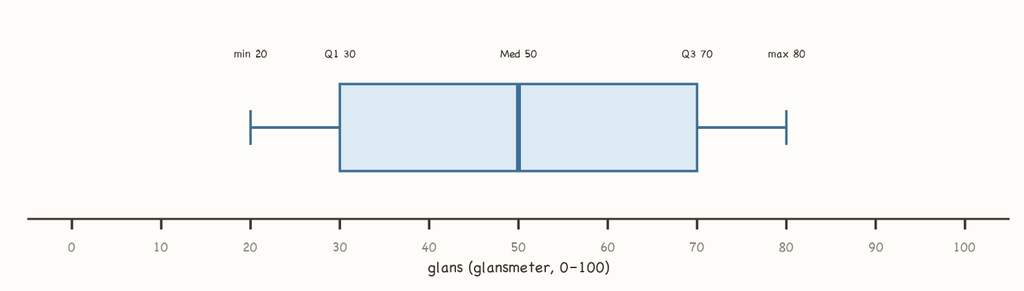

Figuur v1; hand-stijl-pas later.

Een boxplot is niets anders dan die vijf getallen als tekening. De doos loopt van Q1 naar Q3 — daar woont de middelste helft. De streep in de doos is de mediaan. De staarten lopen naar buiten toe.

En dan het lezen — want daar zit de winst. **De breedte van elk stuk vertelt je waar de diamantjes op elkaar lijken en waar ze uit elkaar lopen.** Een smal stuk = een kwart van de gevallen op een klein stukje schaal: homogeen, een kluitje. Een breed stuk = datzelfde kwart uitgesmeerd: heterogeen. Bib-unit boxplot-breedtes; bij de diamantjes: het stuk 30–50 en 50–70 vergelijken.

**Uitbijters en de anderhalf-keer-regel.** Hoe lang mag een staart? De afspraak: maximaal $1{,}5 \times$ de doos-breedte (de *interkwartielrange*, $\mathit{IQR}$ = $Q_3$ − $Q_1$). Bij ons: $\mathit{IQR}$ = 40, dus staarten mogen tot 60 onder $Q_1$ en 60 boven $Q_3$ — van −30 tot 130. Alle twaalf glans-scores vallen daar ruim binnen: geen uitbijters, geen sterretjes. GROF: het reken-ritueel (“ik begin aan de kant waar het raar gaat worden”) bewaren voor een voorbeeld mét uitbijter — zie sectie 4.

## 3. De hoop — stapelen en vorm

Er is nog een tweede manier om de rij vorm te geven: niet uitleggen maar **opstapelen**. Zet alle dertig-ers op één stapel, alle vijftig-ers op de volgende, en zo verder. Dan krijg je een reeks stapels — een *histogram*, maar onthou vooral het beeld: **de hoop**.

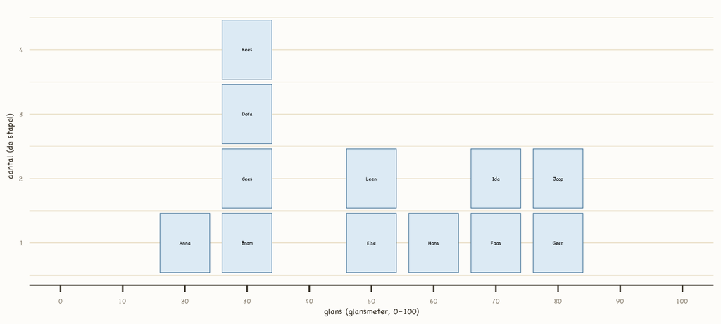

Figuur v1. Term-blokje modus. Diamantjes: modus 30, mediaan 50, gemiddelde 50 — drie “middens” die niet hetzelfde hoeven te zijn, en dat is geen fout maar vorm-informatie. Hier oogst het gat uit §2: de modus woont bij het kluitje onderin, maar mediaan én gemiddelde wonen allebei op 50 — precies in het stilste stuk van de rij, waar bijna niemand woont. Dit als demonstratie van “wie alleen het gemiddelde bewaart, gooit de rij weg” — geen nieuwe spreuk ernaast.

En hopen hebben vormen. Sommige zijn netjes **symmetrisch**: links en rechts van het midden hetzelfde silhouet. Sommige zijn **scheef**: het gros op een kluitje aan één kant, en een lange, dunne **staart** naar de andere kant. De staart geeft de naam: staart naar rechts = rechts-scheef.

## 4. Wat het gemiddelde niet vertelt — Willem-Alexander

GROF — Bens klas-anker, vrijwel verbatim uit de Bib. Alledaags mens-voorbeeld tussen de dieren: mag, werkt juist goed.

Stel, Willem-Alexander komt bij jou in de straat wonen.

Acht huizen op de Koningslaan. Zeven daarvan zijn gewone huizen — vier, vijf, zes ton, zo’n beetje wat een huis kost. En dan hij, met iets waar je een oprijlaan voor nodig hebt: vijfenveertig ton.

Vanaf die dag is de gemiddelde huizenprijs in jouw straat **een miljoen**. Jij hebt niks gedaan. Je woont in hetzelfde huis, met dezelfde scheve dakgoot en dezelfde buurman die zijn heg niet knipt. En toch woon jij nu officieel in een miljoenenstraat. Zet het op je LinkedIn.

Kijk nu naar de mediaan. Het middelste huis is nog steeds het middelste huis: een half miljoen. **De mediaan trekt zich er niks van aan.** Of daarboven een rijtjeshuis staat of een paleis — hij haalt zijn schouders op.

Dat is het woord dat je hier leert: de mediaan is **robuust**. Het gemiddelde is gevoelig — elke score trekt eraan, en een extreme score trekt extreem hard. Terugverwijzing H1: het gemiddelde is het evenwichtspunt van álle residuen — dus een reus aan één kant tilt het hele evenwicht op. De gevoeligheid is geen ontwerpfout; het is dezelfde eigenschap die het gemiddelde de beste gok maakte.

Even voordoen, één keer maar, op de Koningslaan. Gesorteerd: 3, 4, 4, 5, 5, 6, 8, 45.

Q1 is de mediaan van de vier linkse: tussen 4 en 4 in, dus 4. Q3 is de mediaan van de vier rechtse: tussen 6 en 8 in, dus 7. De doos is dus 3 ton breed — dat is je IQR.

Anderhalf keer 3 is 4.5. Ik begin altijd aan de kant waar het raar gaat worden: 7 + 4.5 = 11.5. Alles boven 11.5 ton is uitbijter. Vijfenveertig. Sterretje. Aan de onderkant: 4 − 4.5 = −0.5, en niemand woont voor niks, dus daar gebeurt niks.

En let nu op, want hier gaan mensen de mist in.

**Die grens is geen huis.** Het is een afspraak, een streepje dat wij ergens neerleggen. Er hóéft daar niks te staan, en meestal staat er ook niks. De snor loopt dus niet tot aan de grens — de snor stopt bij het laatste échte huis dat er nog vóór ligt. Op de Koningslaan is dat het huis van 8 ton: de grens ligt op 11.5, maar de snor houdt op bij 8, want verder naar rechts woont er niemand meer. Behalve hij, en die telt niet mee.

En soms — kijk naar het villapark, onderaan — is dat laatste échte huis precies Q1 zelf. Dan heeft de doos aan die kant **helemaal geen snor**.

Ik zie je kijken. Even meerekenen, want dit is het moment waarop mensen denken dat er iets stuk is. Het villapark: 2, 20, 20, 24, 24, 28, 28, 30. De 2 is de uitbijter — een schuurtje tussen de villa’s, of iemand die zijn huis aan zijn dochter verkocht. Blijven over: zeven huizen, en de goedkoopste daarvan kost 20.

Nu Q1. De onderste helft is 2, 20, 20 en 24; het midden daarvan ligt tussen de twee twintigjes in. Q1 is dus óók 20.

Daar staan ze: **het laagste huis en het eerste kwartiel, op precies dezelfde plek.** Het onderste kwart van die straat ligt tussen 20 en 20. Daar is geen ruimte tussen, dus er valt geen snor te tekenen. Niet kapot, niet vergeten: er wóónt gewoon niemand tussen die twee punten.

Dat is de eerlijkheid van een boxplot. Hij tekent wat er is, en als er niks is tekent hij niks. Je zult ze niet vaak zien, deze — maar als je ’m een keer tegenkomt, weet je nu dat je niks fout hebt gedaan.

En daarmee heb je een gratis **vorm-verklikker**: liggen gemiddelde en mediaan vrijwel op elkaar (zoals bij onze diamantjes: allebei 50), dan is de hoop in evenwicht. Ligt het gemiddelde dúidelijk boven de mediaan, dan hangt er rechts een staart die eraan trekt — rechts-scheef. Eronder: links-scheef.

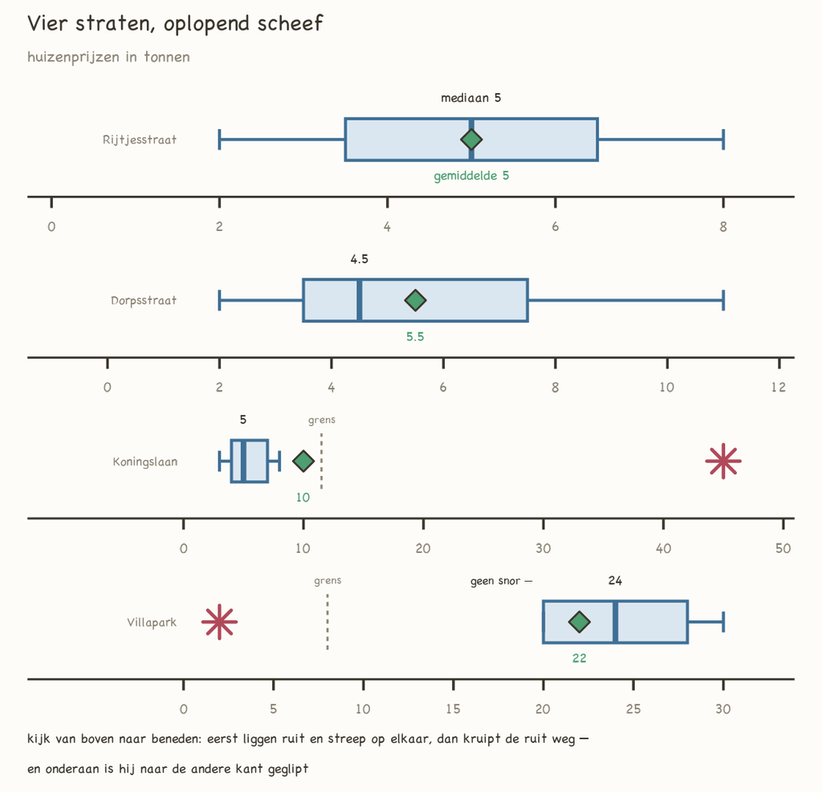

Kijk de vier straten van boven naar beneden en zie het gebeuren: eerst liggen ruit en streep op elkaar, dan kruipt de ruit weg, dan staat hij op het dubbele — en in het villapark is hij naar de ándere kant geglipt. Twee getallen vergelijken, en je ruikt de vorm al voordat je het plaatje ziet.

Vier straten (`_bouw_ontbrekend.R` → `h2_vier_straten.png`). Getallen nagerekend met mediaan-van-de-helft (Bens klasmethode, níét `quantile()` — die interpoleert anders en dan wijkt de figuur af van wat de lezer narekent). **n = 8 per straat is nodig:** bij n = 7 kun je nooit tegelijk een rechtersnor én een uitbijter hebben, want Q3 ís dan de grootste niet-uitbijter (dat was de fout in de oude figuur). A Rijtjesstraat 2,3,4,4,6,6,7,8 → M = Med = 5. B Dorpsstraat 2,3,4,4,5,7,8,11 → M = 5.5, Med = 4.5, géén uitbijter (scheef ≠ uitbijter). C Koningslaan 3,4,4,5,5,6,8,45 → Q1 = 4, Med = 5, Q3 = 7, IQR = 3, grens = 11.5, uitbijter 45, snor tot 8, M = 10 = exact tweemaal de mediaan. D Villapark 2,20,20,24,24,28,28,30 → Q1 = 20, Med = 24, Q3 = 28, IQR = 8, ondergrens 8, uitbijter 2, **linkersnor lengte 0**, M = 22. Let op bij wijzigen: de 45 zet M precies op 10, en de 8 is het énige huis dat de rechtersnor bestaat. Annotaties bewust minimaal — §2 heeft de anatomie al gedaan.

**De regel die dit hoofdstuk achterlaat: teken eerst de hoop, kies dan je samenvatting.** Voor nette, symmetrische hopen vertellen gemiddelde en *SD* het verhaal. Voor scheve hopen met staarten en reuzen vertellen mediaan en kwartielen het eerlijker. Wie blind samenvat, vat het verkeerde samen.

## 5. Werk

Het rekenen mét software — R en JASP — hoort bij het R-oefenboek: *het boek toont, het oefenboek traint.* Sorteren, mediaan, kwartielen, boxplot en histogram doe je daar met je eigen data.

Software-vrij (7-7, keuzes §1). Kiem (sorteren/mediaan/kwartielen/boxplot/histogram + de kwartiel-afrondings-noot): `03_oefenboek_kiemen/R_werk_uit_schetsen_2026-07-11.md`.

## 6. Sluiting

GROF: De dieren lieten de diamantjes bij elkaar, en wij weten nu wat de rij ons geeft: een midden dat nergens van schrikt, kwarten die vertellen waar het kluitert, en een hoop met een vorm. We hebben nu twee samenvattings-talen — gemiddelde-en-spreiding, mediaan-en-kwartielen — en een verklikker om te kiezen.

Maar één vraag is stiekem blijven liggen. Dit was de vorm van óns kistje — twaalf diamantjes op het mos. De rivier waar het kistje uit kwam, heeft óók een vorm. Hoe die eruitziet? Daarvoor moeten we iets doen wat nog niet eerder is vertoond: schudden aan een ton die nooit leeg raakt.

## Open punten (grof → redactie-pas)

- **Verdeel-scène** stem-pas: de kraai-openingszin (“te snel voor iemand die het net pas was ingevallen”) behouden — dat is de toon. Olifant-slot (“dan is de rij weg”) mag misschien nóg kaler.
- **Figuren bouwen:** (1) de rij op een getallenlijn mét namen + rangen;
  2. horizontale boxplot glans; (3) stapels/histogram met torenende 30-stapel; alles in de hand-stijl.
- ✅ **Scheef voorbeeld mét uitbijter** — opgelost 20-7: vier straten (Willem-Alexander-anker), ritueel draait één keer voluit op de Koningslaan incl. sterretje. Nieuw daarbij: de **adjacent-value-parel** (de grens is geen datapunt; de snor stopt bij de laatste échte waarde ervóór) en een bewust **snorloze** boxplot in het villapark.
- **Nog te doen:** de Engelse term *adjacent value* een plek geven in een “Voor wie verder wil”-kader (§8-kadertype) — het idéé staat nu in de hoofdtekst in gewone taal, de term hoort in het kader, niet erbovenop. Variaties op rare boxplots (snorloos aan beide kanten, alles-uitbijter) horen in de oefenboek-schil, niet hier: *boek toont, oefenboek traint.*
- **Kwartiel-conventie**: mediaan-van-de-helft aanhouden (Bens klas-methode); software-afrondingsverschillen alleen als voetnoot in §5.
- **Scheefheid berekenen?** Nee — vorm blijft hier visueel + verklikker (M vs Med); formele skewness-maten zijn geen boek-stof.
- **Zaadje H3 gecheckt**: “kan een steekproef normaal verdeeld zijn? Nee — bij benadering hooguit; assumpties gaan over populaties” (Bib, WA-unit) — bewust NIET hier maar in H3/H5 laten landen; hier alleen de kistje/rivier- cliffhanger.
- **Bib-borging**: verdeel-scène bestaat alleen in deze schets — molen-ronde.
- ✅ **Werk-sectie → tabs (besloten 6-7):** JASP vooraan, R ernaast — sorteren/mediaan/boxplot/histogram kan in beide. Zie keuzes.md §1.

Een boek in wording je leest mee terwijl het zijn vorm vindt